# covid_research

## COVID-19 Data Mining

Task: Find the importance of government responses to COVID-19

Jupyter Notebook:

- Business Understanding
- Data Understanding
- Data Preparation
- Modeling

## 1. Business Understanding

The rapid spread of COVID-19 globally has created a wide range of responses from governments. Common measures include school closings, travel restrictions, bans on public gatherings, emergency investments in healthcare facilities, new forms of social welfare provision, contact tracing and other interventions to contain the spread of the virus, augment health systems, and manage the economic consequences of these actions. However, governments have varied substantially—both across countries, and often within countries—in the measures that they have adopted and how quickly they have adopted them. This variation has created debate as policymakers and publics deliberate over the level of response that should be pursued and how quickly to implement them or roll them back, and as public health experts learn in real time the measures that are more or less effective. (Petherick, 2020)

### 1.1. The Oxford COVID-19 Government Response Tracker

The Oxford COVID-19 Government Response Tracker (OxCGRT) provides a systematic cross-national, cross-temporal measure to understand how government responses have evolved over the full period of the disease’s spread. The project tracks governments’ policies and interventions across a standardized series of indicators and creates a suite of composites indices to measure the extent of these responses. Data is collected and updated in real time by a team of over one hundred Oxford students, alumni and staff, and project partners. (Petherick, 2020)

### 1.2. Data

The data is collected from publicly available information by a cross-disciplinary Oxford University team of academics and students from every part of the world, led by the Blavatnik School of Government. We collate publicly available information on a number of indicators of government response. (OxCGRT, 2020)

## 2. Data Understanding

### 2.1. Features

#### Containment and closure

- C1 School closing - Ordinal
- C2 Workplace closing - Ordinal
- C3 Cancel public events - Ordinal
- C4 Restrictions on gathering size - Ordinal
- C5 Close public transport - Ordinal
- C6 Stay at home requirements - Ordinal
- C7 Restrictions on internal movement - Ordinal
- C8 Restrictions on international travel - Ordinal

#### Economic response

- E1 income support - Ordinal
- E2 debt/contract relief for households - Ordinal
- E3 fiscal measures - Numeric
- E4 giving international support - Numeric

#### Health systems

- H1 Public information campaign - Ordinal
- H2 Testing policy - Ordinal
- H3 Contact tracing - Ordinal
- H4 Emergency investment in healthcare - Numeric
- H5 Investment in Covid-19 vaccines - Numeric
- H6 Facial coverings - Ordinal

#### Miscellaneous

- Other responses - Text

### 2.2. Indicators

- Ordinal indicators measure policies on a simple scale of severity / intensity. These indicators are reported for each day a policy is in place. Many have a further flag to note if they are “targeted”, applying only to a sub-region of a jurisdiction, or a specific sector; or “general”, applying throughout that jurisdiction or across the economy. (Petherick, 2020)
- Numeric indicators measure a specific number, typically the value in USD. These indicators are only reported on the day they are announced. (Petherick, 2020)

### 2.3. Predictors

As predictors just the features used for counting of 'strigency factor' (Petherick, 2020) are used. The other features do not have direct impact on reduction of new COVID cases. These predictors are used:

- C1 School closing - Ordinal
- C2 Workplace closing - Ordinal
- C3 Cancel public events - Ordinal
- C4 Restrictions on gathering size - Ordinal
- C5 Close public transport - Ordinal
- C6 Stay at home requirements - Ordinal
- C7 Restrictions on internal movement - Ordinal
- C8 Restrictions on international travel - Ordinal
- H1 Public information campaign - Ordinal

# 2.4. Import CSV

- The file is from this address: https://raw.githubusercontent.com/OxCGRT/covid-policy-tracker/master/data/OxCGRT_latest.csv
- Data imported on the 10th of February 2021

```python
import pandas as pd
import numpy as np
pd.set_option('display.max_columns', 200)
pd.set_option('display.max_rows', 400)
np.random.seed(seed=42)
```

```python
data = pd.read_csv("./data/20210210.csv", parse_dates=[5], header=0, low_memory=False)
data.head(10)
```

|  | CountryName | CountryCode | RegionName | RegionCode | Jurisdiction | Date | C1_School closing | C1_Flag | C2_Workplace closing | C2_Flag | C3_Cancel public events | C3_Flag | C4_Restrictions on gatherings | C4_Flag | C5_Close public transport | C5_Flag | C6_Stay at home requirements | C6_Flag | C7_Restrictions on internal movement | C7_Flag | C8_International travel controls | E1_Income support | E1_Flag | E2_Debt/contract relief | E3_Fiscal measures | E4_International support | H1_Public information campaigns | H1_Flag | H2_Testing policy | … |
| --- | --- | --- | --- | --- | --- | --- | --- | --- | --- | --- | --- | --- | --- | --- | --- | --- | --- | --- | --- | --- | --- | --- | --- | --- | --- | --- | --- | --- | --- | --- |
| 0 | Aruba | ABW | NaN | NaN | NAT_TOTAL | 2020-01-01 | 0.0 | NaN | 0.0 | NaN | 0.0 | NaN | 0.0 | NaN | 0.0 | NaN | 0.0 | NaN | 0.0 | NaN | 0.0 | 0.0 | NaN | 0.0 | 0.0 | 0.0 | 0.0 | NaN | 0.0 | … |
| 1 | Aruba | ABW | NaN | NaN | NAT_TOTAL | 2020-01-02 | 0.0 | NaN | 0.0 | NaN | 0.0 | NaN | 0.0 | NaN | 0.0 | NaN | 0.0 | NaN | 0.0 | NaN | 0.0 | 0.0 | NaN | 0.0 | 0.0 | 0.0 | 0.0 | NaN | 0.0 | … |
| 2 | Aruba | ABW | NaN | NaN | NAT_TOTAL | 2020-01-03 | 0.0 | NaN | 0.0 | NaN | 0.0 | NaN | 0.0 | NaN | 0.0 | NaN | 0.0 | NaN | 0.0 | NaN | 0.0 | 0.0 | NaN | 0.0 | 0.0 | 0.0 | 0.0 | NaN | 0.0 | … |
| 3 | Aruba | ABW | NaN | NaN | NAT_TOTAL | 2020-01-04 | 0.0 | NaN | 0.0 | NaN | 0.0 | NaN | 0.0 | NaN | 0.0 | NaN | 0.0 | NaN | 0.0 | NaN | 0.0 | 0.0 | NaN | 0.0 | 0.0 | 0.0 | 0.0 | NaN | 0.0 | … |
| 4 | Aruba | ABW | NaN | NaN | NAT_TOTAL | 2020-01-05 | 0.0 | NaN | 0.0 | NaN | 0.0 | NaN | 0.0 | NaN | 0.0 | NaN | 0.0 | NaN | 0.0 | NaN | 0.0 | 0.0 | NaN | 0.0 | 0.0 | 0.0 | 0.0 | NaN | 0.0 | … |
| 5 | Aruba | ABW | NaN | NaN | NAT_TOTAL | 2020-01-06 | 0.0 | NaN | 0.0 | NaN | 0.0 | NaN | 0.0 | NaN | 0.0 | NaN | 0.0 | NaN | 0.0 | NaN | 0.0 | 0.0 | NaN | 0.0 | 0.0 | 0.0 | 0.0 | NaN | 0.0 | … |
| 6 | Aruba | ABW | NaN | NaN | NAT_TOTAL | 2020-01-07 | 0.0 | NaN | 0.0 | NaN | 0.0 | NaN | 0.0 | NaN | 0.0 | NaN | 0.0 | NaN | 0.0 | NaN | 0.0 | 0.0 | NaN | 0.0 | 0.0 | 0.0 | 0.0 | NaN | 0.0 | … |
| 7 | Aruba | ABW | NaN | NaN | NAT_TOTAL | 2020-01-08 | 0.0 | NaN | 0.0 | NaN | 0.0 | NaN | 0.0 | NaN | 0.0 | NaN | 0.0 | NaN | 0.0 | NaN | 0.0 | 0.0 | NaN | 0.0 | 0.0 | 0.0 | 0.0 | NaN | 0.0 | … |
| 8 | Aruba | ABW | NaN | NaN | NAT_TOTAL | 2020-01-09 | 0.0 | NaN | 0.0 | NaN | 0.0 | NaN | 0.0 | NaN | 0.0 | NaN | 0.0 | NaN | 0.0 | NaN | 0.0 | 0.0 | NaN | 0.0 | 0.0 | 0.0 | 0.0 | NaN | 0.0 | … |
| 9 | Aruba | ABW | NaN | NaN | NAT_TOTAL | 2020-01-10 | 0.0 | NaN | 0.0 | NaN | 0.0 | NaN | 0.0 | NaN | 0.0 | NaN | 0.0 | NaN | 0.0 | NaN | 0.0 | 0.0 | NaN | 0.0 | 0.0 | 0.0 | 0.0 | NaN | 0.0 | … |

### 2.5. Statistics for numeric values

Ordinal numbers can be used as numeric numbers because they have clear order for all the values.

```python
data.describe()
```

|  | C1_School closing | C1_Flag | C2_Workplace closing | C2_Flag | C3_Cancel public events | C3_Flag | C4_Restrictions on gatherings | C4_Flag | C5_Close public transport | C5_Flag | C6_Stay at home requirements | C6_Flag | C7_Restrictions on internal movement | C7_Flag | C8_International travel controls | E1_Income support | E1_Flag | E2_Debt/contract relief | E3_Fiscal measures | E4_International support | H1_Public information campaigns | H1_Flag | H2_Testing policy | H3_Contact tracing | H4_Emergency investment in healthcare | H5_Investment in vaccines | H6_Facial Coverings | H6_Flag | H7_Vaccination policy | … |
| --- | --- | --- | --- | --- | --- | --- | --- | --- | --- | --- | --- | --- | --- | --- | --- | --- | --- | --- | --- | --- | --- | --- | --- | --- | --- | --- | --- | --- | --- | --- |
| count | 110629.000000 | 85903.000000 | 110614.000000 | 79075.000000 | 110623.000000 | 85372.000000 | 110630.000000 | 80368.000000 | 110649.000000 | 47346.000000 | 110645.000000 | 69495.000000 | 110669.00000 | 65035.000000 | 109696.000000 | 109386.000000 | 60630.000000 | 108887.000000 | 8.830600e+04 | 8.834300e+04 | 110454.000000 | 98450.000000 | 110470.000000 | 109951.000000 | 8.785400e+04 | 8.836500e+04 | 109990.000000 | 75146.000000 | 93575.000000 | … |
| mean | 1.815356 | 0.786387 | 1.387031 | 0.766399 | 1.336530 | 0.867662 | 2.419064 | 0.805084 | 0.542725 | 0.659992 | 0.942248 | 0.755090 | 0.93654 | 0.682017 | 2.468723 | 0.815360 | 0.504354 | 0.947946 | 1.422033e+08 | 1.021987e+07 | 1.722654 | 0.991133 | 1.632235 | 1.309838 | 9.264629e+06 | 5.745780e+05 | 1.888635 | 0.844343 | 0.134726 | … |
| std | 1.193727 | 0.409859 | 1.034993 | 0.423124 | 0.824504 | 0.338860 | 1.628309 | 0.396138 | 0.691261 | 0.473716 | 0.861463 | 0.430037 | 0.87018 | 0.465696 | 1.342978 | 0.820197 | 0.499985 | 0.813659 | 1.021749e+10 | 2.809815e+09 | 0.646364 | 0.093749 | 0.964617 | 0.766652 | 1.012130e+09 | 6.236689e+07 | 1.495179 | 0.362532 | 0.548544 | … |
| min | 0.000000 | 0.000000 | 0.000000 | 0.000000 | 0.000000 | 0.000000 | 0.000000 | 0.000000 | 0.000000 | 0.000000 | 0.000000 | 0.000000 | 0.00000 | 0.000000 | 0.000000 | 0.000000 | 0.000000 | 0.000000 | -1.000000e-02 | -2.000000e-02 | 0.000000 | 0.000000 | 0.000000 | 0.000000 | 0.000000e+00 | 0.000000e+00 | 0.000000 | 0.000000 | 0.000000 | … |
| 25% | 1.000000 | 1.000000 | 0.000000 | 1.000000 | 1.000000 | 1.000000 | 0.000000 | 1.000000 | 0.000000 | 0.000000 | 0.000000 | 1.000000 | 0.00000 | 0.000000 | 2.000000 | 0.000000 | 0.000000 | 0.000000 | 0.000000e+00 | 0.000000e+00 | 2.000000 | 1.000000 | 1.000000 | 1.000000 | 0.000000e+00 | 0.000000e+00 | 0.000000 | 1.000000 | 0.000000 | … |
| 50% | 2.000000 | 1.000000 | 2.000000 | 1.000000 | 2.000000 | 1.000000 | 3.000000 | 1.000000 | 0.000000 | 1.000000 | 1.000000 | 1.000000 | 1.00000 | 1.000000 | 3.000000 | 1.000000 | 1.000000 | 1.000000 | 0.000000e+00 | 0.000000e+00 | 2.000000 | 1.000000 | 2.000000 | 1.000000 | 0.000000e+00 | 0.000000e+00 | 2.000000 | 1.000000 | 0.000000 | … |
| 75% | 3.000000 | 1.000000 | 2.000000 | 1.000000 | 2.000000 | 1.000000 | 4.000000 | 1.000000 | 1.000000 | 1.000000 | 2.000000 | 1.000000 | 2.00000 | 1.000000 | 4.000000 | 2.000000 | 1.000000 | 2.000000 | 0.000000e+00 | 0.000000e+00 | 2.000000 | 1.000000 | 2.000000 | 2.000000 | 0.000000e+00 | 0.000000e+00 | 3.000000 | 1.000000 | 0.000000 | … |
| max | 3.000000 | 1.000000 | 3.000000 | 1.000000 | 2.000000 | 1.000000 | 4.000000 | 1.000000 | 2.000000 | 1.000000 | 3.000000 | 1.000000 | 2.00000 | 1.000000 | 4.000000 | 2.000000 | 1.000000 | 2.000000 | 1.957600e+12 | 8.343531e+11 | 2.000000 | 1.000000 | 3.000000 | 2.000000 | 2.424000e+11 | 1.575000e+10 | 4.000000 | 1.000000 | 5.000000 | … |

### 2.6. Statistics for categorical values

```python
data.describe(include=np.object)
```

|  | CountryName | CountryCode | RegionName | RegionCode | Jurisdiction |
| --- | --- | --- | --- | --- | --- |
| count | 113960 | 113960 | 38665 | 38665 | 113960 |
| unique | 185 | 185 | 95 | 95 | 2 |
| top | United States | USA | Yukon | US_GA | NAT_TOTAL |
| freq | 21164 | 21164 | 407 | 407 | 75295 |

### 2.7. Missing values

```python
data.isnull().sum()
```

```
CountryName                                   0
CountryCode                                   0
RegionName                                75295
RegionCode                                75295
Jurisdiction                                  0
Date                                          0
C1_School closing                          3331
C1_Flag                                   28057
C2_Workplace closing                       3346
C2_Flag                                   34885
C3_Cancel public events                    3337
C3_Flag                                   28588
C4_Restrictions on gatherings              3330
C4_Flag                                   33592
C5_Close public transport                  3311
C5_Flag                                   66614
C6_Stay at home requirements               3315
C6_Flag                                   44465
C7_Restrictions on internal movement       3291
C7_Flag                                   48925
C8_International travel controls           4264
E1_Income support                          4574
E1_Flag                                   53330
E2_Debt/contract relief                    5073
E3_Fiscal measures                        25654
E4_International support                  25617
H1_Public information campaigns            3506
H1_Flag                                   15510
H2_Testing policy                          3490
H3_Contact tracing                         4009
H4_Emergency investment in healthcare     26106
H5_Investment in vaccines                 25595
H6_Facial Coverings                        3970
H6_Flag                                   38814
H7_Vaccination policy                     20385
H7_Flag                                  107957
M1_Wildcard                              113960
ConfirmedCases                            10158
ConfirmedDeaths                           10268
StringencyIndex                            3460
StringencyIndexForDisplay                  2779
StringencyLegacyIndex                      3441
StringencyLegacyIndexForDisplay            2765
GovernmentResponseIndex                    3626
GovernmentResponseIndexForDisplay          2948
ContainmentHealthIndex                     3495
ContainmentHealthIndexForDisplay           2817
EconomicSupportIndex                       5111
EconomicSupportIndexForDisplay             4437
dtype: int64
```

#### Missing values per country

```python
from datetime import timedelta
for reg_code in data['CountryCode'].unique():
    print(reg_code)
    print('-------------')
    print(data[data['CountryCode'] == reg_code].isnull().sum())
    print('_____________')
    print('')
```

```
ABW
-------------
CountryName                                0
CountryCode                                0
RegionName                               407
RegionCode                               407
Jurisdiction                               0
Date                                       0
C1_School closing                          1
C1_Flag                                  183
C2_Workplace closing                       1
C2_Flag                                  173
C3_Cancel public events                    1
C3_Flag                                   89
C4_Restrictions on gatherings              1
C4_Flag                                  167
C5_Close public transport                  1
C5_Flag                                  407
C6_Stay at home requirements               1
C6_Flag                                  121
C7_Restrictions on internal movement       1
C7_Flag                                  245
C8_International travel controls           1
E1_Income support                          1
E1_Flag                                  132
E2_Debt/contract relief                    1
E3_Fiscal measures                         1
E4_International support                   1
H1_Public information campaigns            1
H1_Flag                                   78
H2_Testing policy                          1
H3_Contact tracing                         1
H4_Emergency investment in healthcare      1
H5_Investment in vaccines                  1
H6_Facial Coverings                        2
H6_Flag                                  218
H7_Vaccination policy                      1
H7_Flag                                  407
M1_Wildcard                              407
ConfirmedCases                            22
```

[output cut: 9934 more lines]

```
M1_Wildcard                              407
ConfirmedCases                            22
ConfirmedDeaths                           22
StringencyIndex                            2
StringencyIndexForDisplay                  0
StringencyLegacyIndex                      2
StringencyLegacyIndexForDisplay            0
GovernmentResponseIndex                    2
GovernmentResponseIndexForDisplay          0
ContainmentHealthIndex                     2
ContainmentHealthIndexForDisplay           0
EconomicSupportIndex                       2
EconomicSupportIndexForDisplay             0
dtype: int64
_____________
```

### 2.8. Size of dataframe

```python
data.shape
```

```
(113960, 49)
```

### 2.9. Target - Confirmed Cases and Confirmed Deaths

See the total number over all coutries.

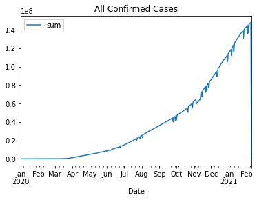

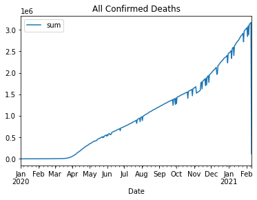

```python
grouped_daily = data.groupby(data.Date).agg(['sum'])
grouped_daily.plot(y='ConfirmedCases', use_index=True, kind="line", title="All Confirmed Cases")
grouped_daily.plot(y='ConfirmedDeaths', use_index=True, kind="line", title="All Confirmed Deaths")
```

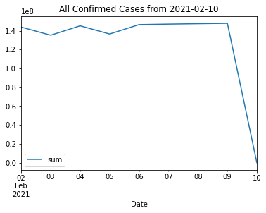

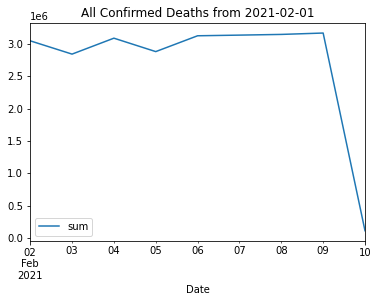

```python
grouped_daily[grouped_daily.index > pd.Timestamp('2021-02-01')].plot(y='ConfirmedCases', use_index=True, kind="line", title="All Confirmed Cases from 2021-02-10")
grouped_daily[grouped_daily.index > pd.Timestamp('2021-02-01')].plot(y='ConfirmedDeaths', use_index=True, kind="line", title="All Confirmed Deaths from 2021-02-01")
```

## 3. Data Preparation

```python
data = data[data.Date < pd.Timestamp('2021-02-08')]
```

### Just EU countries

```python
eu_countries = [
    'AUT',
    'BEL',
    'BGR',
    'HRV',
    'CYP',
    'CZE',
    'DNK',
    'EST',
    'FIN',
    'FRA',
    'DEU',
    'GRC',
    'HUN',
    'IRL',
    'ITA',
    'LVA',
    'LTU',
    'LUX',
    'MLT',
    'NLD',
    'POL',
    'PRT',
    'ROU',
    'SVK',
    'SVN',
    'ESP',
    'SWE',
    'GBR'
]

data = data[data['CountryCode'].isin(eu_countries)]
```

### 3.2. Country and Region to CountryRegionCode

Some countries are separated to regions (for example states in USA). Unique values need to be generated by merging country names and region names.

```python
data['CountryRegionCode'] = data['CountryCode'].add(data['RegionCode'], fill_value='')
data
```

|  | CountryName | CountryCode | RegionName | RegionCode | Jurisdiction | Date | C1_School closing | C1_Flag | C2_Workplace closing | C2_Flag | C3_Cancel public events | C3_Flag | C4_Restrictions on gatherings | C4_Flag | C5_Close public transport | C5_Flag | C6_Stay at home requirements | C6_Flag | C7_Restrictions on internal movement | C7_Flag | C8_International travel controls | E1_Income support | E1_Flag | E2_Debt/contract relief | E3_Fiscal measures | E4_International support | H1_Public information campaigns | H1_Flag | H2_Testing policy | … |
| --- | --- | --- | --- | --- | --- | --- | --- | --- | --- | --- | --- | --- | --- | --- | --- | --- | --- | --- | --- | --- | --- | --- | --- | --- | --- | --- | --- | --- | --- | --- |
| 3256 | Austria | AUT | NaN | NaN | NAT_TOTAL | 2020-01-01 | 0.0 | NaN | 0.0 | NaN | 0.0 | NaN | 0.0 | NaN | 0.0 | NaN | 0.0 | NaN | 0.0 | NaN | 0.0 | 0.0 | NaN | 0.0 | 0.0 | 0.0 | 0.0 | NaN | 0.0 | … |
| 3257 | Austria | AUT | NaN | NaN | NAT_TOTAL | 2020-01-02 | 0.0 | NaN | 0.0 | NaN | 0.0 | NaN | 0.0 | NaN | 0.0 | NaN | 0.0 | NaN | 0.0 | NaN | 0.0 | 0.0 | NaN | 0.0 | 0.0 | 0.0 | 0.0 | NaN | 0.0 | … |
| 3258 | Austria | AUT | NaN | NaN | NAT_TOTAL | 2020-01-03 | 0.0 | NaN | 0.0 | NaN | 0.0 | NaN | 0.0 | NaN | 0.0 | NaN | 0.0 | NaN | 0.0 | NaN | 0.0 | 0.0 | NaN | 0.0 | 0.0 | 0.0 | 0.0 | NaN | 0.0 | … |
| 3259 | Austria | AUT | NaN | NaN | NAT_TOTAL | 2020-01-04 | 0.0 | NaN | 0.0 | NaN | 0.0 | NaN | 0.0 | NaN | 0.0 | NaN | 0.0 | NaN | 0.0 | NaN | 0.0 | 0.0 | NaN | 0.0 | 0.0 | 0.0 | 0.0 | NaN | 0.0 | … |
| 3260 | Austria | AUT | NaN | NaN | NAT_TOTAL | 2020-01-05 | 0.0 | NaN | 0.0 | NaN | 0.0 | NaN | 0.0 | NaN | 0.0 | NaN | 0.0 | NaN | 0.0 | NaN | 0.0 | 0.0 | NaN | 0.0 | 0.0 | 0.0 | 0.0 | NaN | 0.0 | … |
| ... | ... | ... | ... | ... | ... | ... | ... | ... | ... | ... | ... | ... | ... | ... | ... | ... | ... | ... | ... | ... | ... | ... | ... | ... | ... | ... | ... | ... | ... | … |
| 81799 | Sweden | SWE | NaN | NaN | NAT_TOTAL | 2021-02-03 | 2.0 | 0.0 | 2.0 | 1.0 | 2.0 | 1.0 | 4.0 | 1.0 | 1.0 | 1.0 | 1.0 | 1.0 | 1.0 | 1.0 | 3.0 | 2.0 | 0.0 | 0.0 | 0.0 | 0.0 | 2.0 | 1.0 | 2.0 | … |
| 81800 | Sweden | SWE | NaN | NaN | NAT_TOTAL | 2021-02-04 | 2.0 | 0.0 | 2.0 | 1.0 | 2.0 | 1.0 | 4.0 | 1.0 | 1.0 | 1.0 | 1.0 | 1.0 | 1.0 | 1.0 | 3.0 | 2.0 | 0.0 | 0.0 | 0.0 | 0.0 | 2.0 | 1.0 | 2.0 | … |
| 81801 | Sweden | SWE | NaN | NaN | NAT_TOTAL | 2021-02-05 | 2.0 | 0.0 | 2.0 | 1.0 | 2.0 | 1.0 | 4.0 | 1.0 | 1.0 | 1.0 | 1.0 | 1.0 | 1.0 | 1.0 | 3.0 | 2.0 | 0.0 | 0.0 | 0.0 | 0.0 | 2.0 | 1.0 | 2.0 | … |
| 81802 | Sweden | SWE | NaN | NaN | NAT_TOTAL | 2021-02-06 | NaN | NaN | NaN | NaN | NaN | NaN | NaN | NaN | NaN | NaN | NaN | NaN | NaN | NaN | NaN | NaN | NaN | NaN | NaN | NaN | NaN | NaN | NaN | … |
| 81803 | Sweden | SWE | NaN | NaN | NAT_TOTAL | 2021-02-07 | NaN | NaN | NaN | NaN | NaN | NaN | NaN | NaN | NaN | NaN | NaN | NaN | NaN | NaN | NaN | NaN | NaN | NaN | NaN | NaN | NaN | NaN | NaN | … |

12928 rows × 50 columns

### 3.3. Remove all CountryRegionCodes where more than 70 missing values for ConfirmedDeaths or ConfirmedCases

```python
data = data.groupby('CountryRegionCode').filter(lambda s: s['ConfirmedCases'].isnull().sum() <= 70)
data = data.groupby('CountryRegionCode').filter(lambda s: s['ConfirmedDeaths'].isnull().sum() <= 70)
data
```

|  | CountryName | CountryCode | RegionName | RegionCode | Jurisdiction | Date | C1_School closing | C1_Flag | C2_Workplace closing | C2_Flag | C3_Cancel public events | C3_Flag | C4_Restrictions on gatherings | C4_Flag | C5_Close public transport | C5_Flag | C6_Stay at home requirements | C6_Flag | C7_Restrictions on internal movement | C7_Flag | C8_International travel controls | E1_Income support | E1_Flag | E2_Debt/contract relief | E3_Fiscal measures | E4_International support | H1_Public information campaigns | H1_Flag | H2_Testing policy | … |
| --- | --- | --- | --- | --- | --- | --- | --- | --- | --- | --- | --- | --- | --- | --- | --- | --- | --- | --- | --- | --- | --- | --- | --- | --- | --- | --- | --- | --- | --- | --- |
| 3256 | Austria | AUT | NaN | NaN | NAT_TOTAL | 2020-01-01 | 0.0 | NaN | 0.0 | NaN | 0.0 | NaN | 0.0 | NaN | 0.0 | NaN | 0.0 | NaN | 0.0 | NaN | 0.0 | 0.0 | NaN | 0.0 | 0.0 | 0.0 | 0.0 | NaN | 0.0 | … |
| 3257 | Austria | AUT | NaN | NaN | NAT_TOTAL | 2020-01-02 | 0.0 | NaN | 0.0 | NaN | 0.0 | NaN | 0.0 | NaN | 0.0 | NaN | 0.0 | NaN | 0.0 | NaN | 0.0 | 0.0 | NaN | 0.0 | 0.0 | 0.0 | 0.0 | NaN | 0.0 | … |
| 3258 | Austria | AUT | NaN | NaN | NAT_TOTAL | 2020-01-03 | 0.0 | NaN | 0.0 | NaN | 0.0 | NaN | 0.0 | NaN | 0.0 | NaN | 0.0 | NaN | 0.0 | NaN | 0.0 | 0.0 | NaN | 0.0 | 0.0 | 0.0 | 0.0 | NaN | 0.0 | … |
| 3259 | Austria | AUT | NaN | NaN | NAT_TOTAL | 2020-01-04 | 0.0 | NaN | 0.0 | NaN | 0.0 | NaN | 0.0 | NaN | 0.0 | NaN | 0.0 | NaN | 0.0 | NaN | 0.0 | 0.0 | NaN | 0.0 | 0.0 | 0.0 | 0.0 | NaN | 0.0 | … |
| 3260 | Austria | AUT | NaN | NaN | NAT_TOTAL | 2020-01-05 | 0.0 | NaN | 0.0 | NaN | 0.0 | NaN | 0.0 | NaN | 0.0 | NaN | 0.0 | NaN | 0.0 | NaN | 0.0 | 0.0 | NaN | 0.0 | 0.0 | 0.0 | 0.0 | NaN | 0.0 | … |
| ... | ... | ... | ... | ... | ... | ... | ... | ... | ... | ... | ... | ... | ... | ... | ... | ... | ... | ... | ... | ... | ... | ... | ... | ... | ... | ... | ... | ... | ... | … |
| 81799 | Sweden | SWE | NaN | NaN | NAT_TOTAL | 2021-02-03 | 2.0 | 0.0 | 2.0 | 1.0 | 2.0 | 1.0 | 4.0 | 1.0 | 1.0 | 1.0 | 1.0 | 1.0 | 1.0 | 1.0 | 3.0 | 2.0 | 0.0 | 0.0 | 0.0 | 0.0 | 2.0 | 1.0 | 2.0 | … |
| 81800 | Sweden | SWE | NaN | NaN | NAT_TOTAL | 2021-02-04 | 2.0 | 0.0 | 2.0 | 1.0 | 2.0 | 1.0 | 4.0 | 1.0 | 1.0 | 1.0 | 1.0 | 1.0 | 1.0 | 1.0 | 3.0 | 2.0 | 0.0 | 0.0 | 0.0 | 0.0 | 2.0 | 1.0 | 2.0 | … |
| 81801 | Sweden | SWE | NaN | NaN | NAT_TOTAL | 2021-02-05 | 2.0 | 0.0 | 2.0 | 1.0 | 2.0 | 1.0 | 4.0 | 1.0 | 1.0 | 1.0 | 1.0 | 1.0 | 1.0 | 1.0 | 3.0 | 2.0 | 0.0 | 0.0 | 0.0 | 0.0 | 2.0 | 1.0 | 2.0 | … |
| 81802 | Sweden | SWE | NaN | NaN | NAT_TOTAL | 2021-02-06 | NaN | NaN | NaN | NaN | NaN | NaN | NaN | NaN | NaN | NaN | NaN | NaN | NaN | NaN | NaN | NaN | NaN | NaN | NaN | NaN | NaN | NaN | NaN | … |
| 81803 | Sweden | SWE | NaN | NaN | NAT_TOTAL | 2021-02-07 | NaN | NaN | NaN | NaN | NaN | NaN | NaN | NaN | NaN | NaN | NaN | NaN | NaN | NaN | NaN | NaN | NaN | NaN | NaN | NaN | NaN | NaN | NaN | … |

11716 rows × 50 columns

### 3.4. Missing values

Interpolate values in forward direction. Then missing values in the beginnings of epochs replace with 0. It needs to be done for each combination of country and region.

#### Targets

```python
original_targets = ['ConfirmedCases', 'ConfirmedDeaths']
for reg_code in data['CountryRegionCode'].unique():
    data.update(data[data['CountryRegionCode'] == reg_code][original_targets].interpolate(method ='linear', limit_direction ='forward').fillna(0))
data
```

|  | CountryName | CountryCode | RegionName | RegionCode | Jurisdiction | Date | C1_School closing | C1_Flag | C2_Workplace closing | C2_Flag | C3_Cancel public events | C3_Flag | C4_Restrictions on gatherings | C4_Flag | C5_Close public transport | C5_Flag | C6_Stay at home requirements | C6_Flag | C7_Restrictions on internal movement | C7_Flag | C8_International travel controls | E1_Income support | E1_Flag | E2_Debt/contract relief | E3_Fiscal measures | E4_International support | H1_Public information campaigns | H1_Flag | H2_Testing policy | … |
| --- | --- | --- | --- | --- | --- | --- | --- | --- | --- | --- | --- | --- | --- | --- | --- | --- | --- | --- | --- | --- | --- | --- | --- | --- | --- | --- | --- | --- | --- | --- |
| 3256 | Austria | AUT | NaN | NaN | NAT_TOTAL | 2020-01-01 | 0.0 | NaN | 0.0 | NaN | 0.0 | NaN | 0.0 | NaN | 0.0 | NaN | 0.0 | NaN | 0.0 | NaN | 0.0 | 0.0 | NaN | 0.0 | 0.0 | 0.0 | 0.0 | NaN | 0.0 | … |
| 3257 | Austria | AUT | NaN | NaN | NAT_TOTAL | 2020-01-02 | 0.0 | NaN | 0.0 | NaN | 0.0 | NaN | 0.0 | NaN | 0.0 | NaN | 0.0 | NaN | 0.0 | NaN | 0.0 | 0.0 | NaN | 0.0 | 0.0 | 0.0 | 0.0 | NaN | 0.0 | … |
| 3258 | Austria | AUT | NaN | NaN | NAT_TOTAL | 2020-01-03 | 0.0 | NaN | 0.0 | NaN | 0.0 | NaN | 0.0 | NaN | 0.0 | NaN | 0.0 | NaN | 0.0 | NaN | 0.0 | 0.0 | NaN | 0.0 | 0.0 | 0.0 | 0.0 | NaN | 0.0 | … |
| 3259 | Austria | AUT | NaN | NaN | NAT_TOTAL | 2020-01-04 | 0.0 | NaN | 0.0 | NaN | 0.0 | NaN | 0.0 | NaN | 0.0 | NaN | 0.0 | NaN | 0.0 | NaN | 0.0 | 0.0 | NaN | 0.0 | 0.0 | 0.0 | 0.0 | NaN | 0.0 | … |
| 3260 | Austria | AUT | NaN | NaN | NAT_TOTAL | 2020-01-05 | 0.0 | NaN | 0.0 | NaN | 0.0 | NaN | 0.0 | NaN | 0.0 | NaN | 0.0 | NaN | 0.0 | NaN | 0.0 | 0.0 | NaN | 0.0 | 0.0 | 0.0 | 0.0 | NaN | 0.0 | … |
| ... | ... | ... | ... | ... | ... | ... | ... | ... | ... | ... | ... | ... | ... | ... | ... | ... | ... | ... | ... | ... | ... | ... | ... | ... | ... | ... | ... | ... | ... | … |
| 81799 | Sweden | SWE | NaN | NaN | NAT_TOTAL | 2021-02-03 | 2.0 | 0.0 | 2.0 | 1.0 | 2.0 | 1.0 | 4.0 | 1.0 | 1.0 | 1.0 | 1.0 | 1.0 | 1.0 | 1.0 | 3.0 | 2.0 | 0.0 | 0.0 | 0.0 | 0.0 | 2.0 | 1.0 | 2.0 | … |
| 81800 | Sweden | SWE | NaN | NaN | NAT_TOTAL | 2021-02-04 | 2.0 | 0.0 | 2.0 | 1.0 | 2.0 | 1.0 | 4.0 | 1.0 | 1.0 | 1.0 | 1.0 | 1.0 | 1.0 | 1.0 | 3.0 | 2.0 | 0.0 | 0.0 | 0.0 | 0.0 | 2.0 | 1.0 | 2.0 | … |
| 81801 | Sweden | SWE | NaN | NaN | NAT_TOTAL | 2021-02-05 | 2.0 | 0.0 | 2.0 | 1.0 | 2.0 | 1.0 | 4.0 | 1.0 | 1.0 | 1.0 | 1.0 | 1.0 | 1.0 | 1.0 | 3.0 | 2.0 | 0.0 | 0.0 | 0.0 | 0.0 | 2.0 | 1.0 | 2.0 | … |
| 81802 | Sweden | SWE | NaN | NaN | NAT_TOTAL | 2021-02-06 | NaN | NaN | NaN | NaN | NaN | NaN | NaN | NaN | NaN | NaN | NaN | NaN | NaN | NaN | NaN | NaN | NaN | NaN | NaN | NaN | NaN | NaN | NaN | … |
| 81803 | Sweden | SWE | NaN | NaN | NAT_TOTAL | 2021-02-07 | NaN | NaN | NaN | NaN | NaN | NaN | NaN | NaN | NaN | NaN | NaN | NaN | NaN | NaN | NaN | NaN | NaN | NaN | NaN | NaN | NaN | NaN | NaN | … |

11716 rows × 50 columns

```python
data[original_targets].isnull().sum()
```

```
ConfirmedCases     0
ConfirmedDeaths    0
dtype: int64
```

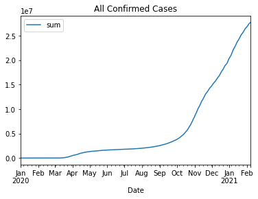

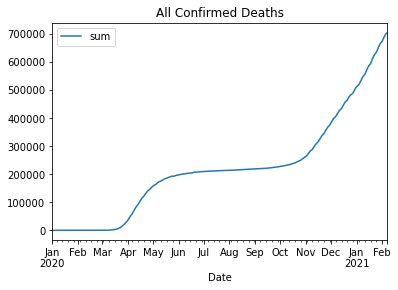

```python
grouped_daily = data.groupby(data.Date).agg(['sum'])
grouped_daily.plot(y='ConfirmedCases', use_index=True, kind="line", title="All Confirmed Cases")
grouped_daily.plot(y='ConfirmedDeaths', use_index=True, kind="line", title="All Confirmed Deaths")
```

#### Predictors

Forward Fill for predictors

```python
predictors = ['C1_School closing', 'C1_Flag', 'C2_Workplace closing', 'C2_Flag', 'C3_Cancel public events', 'C3_Flag', 'C4_Restrictions on gatherings', 'C4_Flag', 'C5_Close public transport', 'C5_Flag', 'C6_Stay at home requirements', 'C6_Flag', 'C7_Restrictions on internal movement', 'C7_Flag', 'C8_International travel controls', 'H1_Public information campaigns', 'H1_Flag']
data.update(data.groupby('CountryRegionCode')[predictors].ffill().fillna(0))
data
```

|  | CountryName | CountryCode | RegionName | RegionCode | Jurisdiction | Date | C1_School closing | C1_Flag | C2_Workplace closing | C2_Flag | C3_Cancel public events | C3_Flag | C4_Restrictions on gatherings | C4_Flag | C5_Close public transport | C5_Flag | C6_Stay at home requirements | C6_Flag | C7_Restrictions on internal movement | C7_Flag | C8_International travel controls | E1_Income support | E1_Flag | E2_Debt/contract relief | E3_Fiscal measures | E4_International support | H1_Public information campaigns | H1_Flag | H2_Testing policy | … |
| --- | --- | --- | --- | --- | --- | --- | --- | --- | --- | --- | --- | --- | --- | --- | --- | --- | --- | --- | --- | --- | --- | --- | --- | --- | --- | --- | --- | --- | --- | --- |
| 3256 | Austria | AUT | NaN | NaN | NAT_TOTAL | 2020-01-01 | 0.0 | 0.0 | 0.0 | 0.0 | 0.0 | 0.0 | 0.0 | 0.0 | 0.0 | 0.0 | 0.0 | 0.0 | 0.0 | 0.0 | 0.0 | 0.0 | NaN | 0.0 | 0.0 | 0.0 | 0.0 | 0.0 | 0.0 | … |
| 3257 | Austria | AUT | NaN | NaN | NAT_TOTAL | 2020-01-02 | 0.0 | 0.0 | 0.0 | 0.0 | 0.0 | 0.0 | 0.0 | 0.0 | 0.0 | 0.0 | 0.0 | 0.0 | 0.0 | 0.0 | 0.0 | 0.0 | NaN | 0.0 | 0.0 | 0.0 | 0.0 | 0.0 | 0.0 | … |
| 3258 | Austria | AUT | NaN | NaN | NAT_TOTAL | 2020-01-03 | 0.0 | 0.0 | 0.0 | 0.0 | 0.0 | 0.0 | 0.0 | 0.0 | 0.0 | 0.0 | 0.0 | 0.0 | 0.0 | 0.0 | 0.0 | 0.0 | NaN | 0.0 | 0.0 | 0.0 | 0.0 | 0.0 | 0.0 | … |
| 3259 | Austria | AUT | NaN | NaN | NAT_TOTAL | 2020-01-04 | 0.0 | 0.0 | 0.0 | 0.0 | 0.0 | 0.0 | 0.0 | 0.0 | 0.0 | 0.0 | 0.0 | 0.0 | 0.0 | 0.0 | 0.0 | 0.0 | NaN | 0.0 | 0.0 | 0.0 | 0.0 | 0.0 | 0.0 | … |
| 3260 | Austria | AUT | NaN | NaN | NAT_TOTAL | 2020-01-05 | 0.0 | 0.0 | 0.0 | 0.0 | 0.0 | 0.0 | 0.0 | 0.0 | 0.0 | 0.0 | 0.0 | 0.0 | 0.0 | 0.0 | 0.0 | 0.0 | NaN | 0.0 | 0.0 | 0.0 | 0.0 | 0.0 | 0.0 | … |
| ... | ... | ... | ... | ... | ... | ... | ... | ... | ... | ... | ... | ... | ... | ... | ... | ... | ... | ... | ... | ... | ... | ... | ... | ... | ... | ... | ... | ... | ... | … |
| 81799 | Sweden | SWE | NaN | NaN | NAT_TOTAL | 2021-02-03 | 2.0 | 0.0 | 2.0 | 1.0 | 2.0 | 1.0 | 4.0 | 1.0 | 1.0 | 1.0 | 1.0 | 1.0 | 1.0 | 1.0 | 3.0 | 2.0 | 0.0 | 0.0 | 0.0 | 0.0 | 2.0 | 1.0 | 2.0 | … |
| 81800 | Sweden | SWE | NaN | NaN | NAT_TOTAL | 2021-02-04 | 2.0 | 0.0 | 2.0 | 1.0 | 2.0 | 1.0 | 4.0 | 1.0 | 1.0 | 1.0 | 1.0 | 1.0 | 1.0 | 1.0 | 3.0 | 2.0 | 0.0 | 0.0 | 0.0 | 0.0 | 2.0 | 1.0 | 2.0 | … |
| 81801 | Sweden | SWE | NaN | NaN | NAT_TOTAL | 2021-02-05 | 2.0 | 0.0 | 2.0 | 1.0 | 2.0 | 1.0 | 4.0 | 1.0 | 1.0 | 1.0 | 1.0 | 1.0 | 1.0 | 1.0 | 3.0 | 2.0 | 0.0 | 0.0 | 0.0 | 0.0 | 2.0 | 1.0 | 2.0 | … |
| 81802 | Sweden | SWE | NaN | NaN | NAT_TOTAL | 2021-02-06 | 2.0 | 0.0 | 2.0 | 1.0 | 2.0 | 1.0 | 4.0 | 1.0 | 1.0 | 1.0 | 1.0 | 1.0 | 1.0 | 1.0 | 3.0 | NaN | NaN | NaN | NaN | NaN | 2.0 | 1.0 | NaN | … |
| 81803 | Sweden | SWE | NaN | NaN | NAT_TOTAL | 2021-02-07 | 2.0 | 0.0 | 2.0 | 1.0 | 2.0 | 1.0 | 4.0 | 1.0 | 1.0 | 1.0 | 1.0 | 1.0 | 1.0 | 1.0 | 3.0 | NaN | NaN | NaN | NaN | NaN | 2.0 | 1.0 | NaN | … |

11716 rows × 50 columns

Check that no missing values are in the dataset.

```python
data[predictors].isnull().sum()
```

```
C1_School closing                       0
C1_Flag                                 0
C2_Workplace closing                    0
C2_Flag                                 0
C3_Cancel public events                 0
C3_Flag                                 0
C4_Restrictions on gatherings           0
C4_Flag                                 0
C5_Close public transport               0
C5_Flag                                 0
C6_Stay at home requirements            0
C6_Flag                                 0
C7_Restrictions on internal movement    0
C7_Flag                                 0
C8_International travel controls        0
H1_Public information campaigns         0
H1_Flag                                 0
dtype: int64
```

#### Strigency Index

Forward Fill for strigency index

```python
data.update(data.groupby('CountryRegionCode')[['StringencyIndex']].ffill().fillna(0))
```

### 3.5. Merge Measure and Flag

Flag explains if the closure was applied in general (1) or just locally (0). In this section new features are created from the measure and its flag. For example the features 'C1_School closing' and 'C1_Flag' are transfered to two new features: 'C1_School closing_local' and 'C1_School closing_general'.

```python
merging_couples = {}
for predictor in predictors:
    code = predictor[:2]
    if code not in merging_couples:
        merging_couples[code] = [predictor]
    else:
        merging_couples[code].append(predictor)
for key, couple in dict(merging_couples).items():
    if len(couple) < 2:
        del merging_couples[key]
merging_couples
```

```
{'C1': ['C1_School closing', 'C1_Flag'],
 'C2': ['C2_Workplace closing', 'C2_Flag'],
 'C3': ['C3_Cancel public events', 'C3_Flag'],
 'C4': ['C4_Restrictions on gatherings', 'C4_Flag'],
 'C5': ['C5_Close public transport', 'C5_Flag'],
 'C6': ['C6_Stay at home requirements', 'C6_Flag'],
 'C7': ['C7_Restrictions on internal movement', 'C7_Flag'],
 'H1': ['H1_Public information campaigns', 'H1_Flag']}
```

```python
for couple in merging_couples.values():
    predictors.remove(couple[0])
    predictors.remove(couple[1])
    col_name = couple[0] + '_general'
    data[col_name] = data[couple[0]]
    data.loc[data[couple[1]] != 1, col_name] = 0
    predictors.append(col_name)
    col_name = couple[0] + '_local'
    data[col_name] = data[couple[0]]
    data.loc[data[couple[1]] == 1, col_name] = 0
    predictors.append(col_name)
data
```

|  | CountryName | CountryCode | RegionName | RegionCode | Jurisdiction | Date | C1_School closing | C1_Flag | C2_Workplace closing | C2_Flag | C3_Cancel public events | C3_Flag | C4_Restrictions on gatherings | C4_Flag | C5_Close public transport | C5_Flag | C6_Stay at home requirements | C6_Flag | C7_Restrictions on internal movement | C7_Flag | C8_International travel controls | E1_Income support | E1_Flag | E2_Debt/contract relief | E3_Fiscal measures | E4_International support | H1_Public information campaigns | H1_Flag | H2_Testing policy | … |
| --- | --- | --- | --- | --- | --- | --- | --- | --- | --- | --- | --- | --- | --- | --- | --- | --- | --- | --- | --- | --- | --- | --- | --- | --- | --- | --- | --- | --- | --- | --- |
| 3256 | Austria | AUT | NaN | NaN | NAT_TOTAL | 2020-01-01 | 0.0 | 0.0 | 0.0 | 0.0 | 0.0 | 0.0 | 0.0 | 0.0 | 0.0 | 0.0 | 0.0 | 0.0 | 0.0 | 0.0 | 0.0 | 0.0 | NaN | 0.0 | 0.0 | 0.0 | 0.0 | 0.0 | 0.0 | … |
| 3257 | Austria | AUT | NaN | NaN | NAT_TOTAL | 2020-01-02 | 0.0 | 0.0 | 0.0 | 0.0 | 0.0 | 0.0 | 0.0 | 0.0 | 0.0 | 0.0 | 0.0 | 0.0 | 0.0 | 0.0 | 0.0 | 0.0 | NaN | 0.0 | 0.0 | 0.0 | 0.0 | 0.0 | 0.0 | … |
| 3258 | Austria | AUT | NaN | NaN | NAT_TOTAL | 2020-01-03 | 0.0 | 0.0 | 0.0 | 0.0 | 0.0 | 0.0 | 0.0 | 0.0 | 0.0 | 0.0 | 0.0 | 0.0 | 0.0 | 0.0 | 0.0 | 0.0 | NaN | 0.0 | 0.0 | 0.0 | 0.0 | 0.0 | 0.0 | … |
| 3259 | Austria | AUT | NaN | NaN | NAT_TOTAL | 2020-01-04 | 0.0 | 0.0 | 0.0 | 0.0 | 0.0 | 0.0 | 0.0 | 0.0 | 0.0 | 0.0 | 0.0 | 0.0 | 0.0 | 0.0 | 0.0 | 0.0 | NaN | 0.0 | 0.0 | 0.0 | 0.0 | 0.0 | 0.0 | … |
| 3260 | Austria | AUT | NaN | NaN | NAT_TOTAL | 2020-01-05 | 0.0 | 0.0 | 0.0 | 0.0 | 0.0 | 0.0 | 0.0 | 0.0 | 0.0 | 0.0 | 0.0 | 0.0 | 0.0 | 0.0 | 0.0 | 0.0 | NaN | 0.0 | 0.0 | 0.0 | 0.0 | 0.0 | 0.0 | … |
| ... | ... | ... | ... | ... | ... | ... | ... | ... | ... | ... | ... | ... | ... | ... | ... | ... | ... | ... | ... | ... | ... | ... | ... | ... | ... | ... | ... | ... | ... | … |
| 81799 | Sweden | SWE | NaN | NaN | NAT_TOTAL | 2021-02-03 | 2.0 | 0.0 | 2.0 | 1.0 | 2.0 | 1.0 | 4.0 | 1.0 | 1.0 | 1.0 | 1.0 | 1.0 | 1.0 | 1.0 | 3.0 | 2.0 | 0.0 | 0.0 | 0.0 | 0.0 | 2.0 | 1.0 | 2.0 | … |
| 81800 | Sweden | SWE | NaN | NaN | NAT_TOTAL | 2021-02-04 | 2.0 | 0.0 | 2.0 | 1.0 | 2.0 | 1.0 | 4.0 | 1.0 | 1.0 | 1.0 | 1.0 | 1.0 | 1.0 | 1.0 | 3.0 | 2.0 | 0.0 | 0.0 | 0.0 | 0.0 | 2.0 | 1.0 | 2.0 | … |
| 81801 | Sweden | SWE | NaN | NaN | NAT_TOTAL | 2021-02-05 | 2.0 | 0.0 | 2.0 | 1.0 | 2.0 | 1.0 | 4.0 | 1.0 | 1.0 | 1.0 | 1.0 | 1.0 | 1.0 | 1.0 | 3.0 | 2.0 | 0.0 | 0.0 | 0.0 | 0.0 | 2.0 | 1.0 | 2.0 | … |
| 81802 | Sweden | SWE | NaN | NaN | NAT_TOTAL | 2021-02-06 | 2.0 | 0.0 | 2.0 | 1.0 | 2.0 | 1.0 | 4.0 | 1.0 | 1.0 | 1.0 | 1.0 | 1.0 | 1.0 | 1.0 | 3.0 | NaN | NaN | NaN | NaN | NaN | 2.0 | 1.0 | NaN | … |
| 81803 | Sweden | SWE | NaN | NaN | NAT_TOTAL | 2021-02-07 | 2.0 | 0.0 | 2.0 | 1.0 | 2.0 | 1.0 | 4.0 | 1.0 | 1.0 | 1.0 | 1.0 | 1.0 | 1.0 | 1.0 | 3.0 | NaN | NaN | NaN | NaN | NaN | 2.0 | 1.0 | NaN | … |

11716 rows × 66 columns

### 3.6. Add Weather Data

Enrich the dataframe with information about weather for each day/country/region.

```python
from wwo_hist import retrieve_hist_data
import urllib.parse
import os
os.chdir('./weather')
```

```python
import time
FREQUENCY = 24 #hours
START_DATE = data.Date.min() #'11-DEC-2018'
END_DATE = data.Date.max()
API_KEY = 'b28bd9c8fdec4aa7b3d132524210503'
LOCATION_LIST = []
for country in data['CountryName'].unique():
    for region in data[data['CountryName'] == country]['RegionName'].unique():
        if country == 'Eswatini':
            country = 'Kingdom of Eswatini'

        if isinstance(region, str):
            LOCATION_LIST.append(urllib.parse.quote(country + ', ' + region)) #
        else:
            LOCATION_LIST.append(urllib.parse.quote(country))

#hist_weather_data = retrieve_hist_data(API_KEY,
#                                LOCATION_LIST,
#                                START_DATE,
#                                END_DATE,
#                                FREQUENCY,
#                                location_label = True,
#                                export_csv = True,
#                                store_df = True)
```

```python
data['RegionName'] = data['RegionName'].fillna('basic')
data_weather = None
for country in data['CountryName'].unique():
    if country == 'Eswatini':
            country = 'Kingdom of Eswatini'
    for region in data[data['CountryName'] == country]['RegionName'].unique():
        if region != 'basic':
            country_data = pd.read_csv(urllib.parse.quote(country + ', ' + region) + ".csv", parse_dates=[0], header=0)
        else:
            country_data = pd.read_csv(urllib.parse.quote(country) + ".csv", parse_dates=[0], header=0)
        country_data = country_data[country_data["date_time"] < pd.Timestamp('2021-02-08')] # time limit
        new_country_cols = []
        for col in country_data.columns:
            new_country_cols.append(col.split('_', 1)[1])
        country_data.columns = new_country_cols
        origin_data = data[(data['CountryName'] == country) & (data['RegionName'] == region)]
        country_data.index = origin_data.index
        data_country_weather = pd.concat([origin_data, country_data.reindex(origin_data.index)], axis=1)
        if type(data_weather) == type(None):
             data_weather = data_country_weather
        else:
            data_weather = data_weather.append(data_country_weather)
data_weather
```

|  | CountryName | CountryCode | RegionName | RegionCode | Jurisdiction | Date | C1_School closing | C1_Flag | C2_Workplace closing | C2_Flag | C3_Cancel public events | C3_Flag | C4_Restrictions on gatherings | C4_Flag | C5_Close public transport | C5_Flag | C6_Stay at home requirements | C6_Flag | C7_Restrictions on internal movement | C7_Flag | C8_International travel controls | E1_Income support | E1_Flag | E2_Debt/contract relief | E3_Fiscal measures | E4_International support | H1_Public information campaigns | H1_Flag | H2_Testing policy | … |
| --- | --- | --- | --- | --- | --- | --- | --- | --- | --- | --- | --- | --- | --- | --- | --- | --- | --- | --- | --- | --- | --- | --- | --- | --- | --- | --- | --- | --- | --- | --- |
| 3256 | Austria | AUT | basic | NaN | NAT_TOTAL | 2020-01-01 | 0.0 | 0.0 | 0.0 | 0.0 | 0.0 | 0.0 | 0.0 | 0.0 | 0.0 | 0.0 | 0.0 | 0.0 | 0.0 | 0.0 | 0.0 | 0.0 | NaN | 0.0 | 0.0 | 0.0 | 0.0 | 0.0 | 0.0 | … |
| 3257 | Austria | AUT | basic | NaN | NAT_TOTAL | 2020-01-02 | 0.0 | 0.0 | 0.0 | 0.0 | 0.0 | 0.0 | 0.0 | 0.0 | 0.0 | 0.0 | 0.0 | 0.0 | 0.0 | 0.0 | 0.0 | 0.0 | NaN | 0.0 | 0.0 | 0.0 | 0.0 | 0.0 | 0.0 | … |
| 3258 | Austria | AUT | basic | NaN | NAT_TOTAL | 2020-01-03 | 0.0 | 0.0 | 0.0 | 0.0 | 0.0 | 0.0 | 0.0 | 0.0 | 0.0 | 0.0 | 0.0 | 0.0 | 0.0 | 0.0 | 0.0 | 0.0 | NaN | 0.0 | 0.0 | 0.0 | 0.0 | 0.0 | 0.0 | … |
| 3259 | Austria | AUT | basic | NaN | NAT_TOTAL | 2020-01-04 | 0.0 | 0.0 | 0.0 | 0.0 | 0.0 | 0.0 | 0.0 | 0.0 | 0.0 | 0.0 | 0.0 | 0.0 | 0.0 | 0.0 | 0.0 | 0.0 | NaN | 0.0 | 0.0 | 0.0 | 0.0 | 0.0 | 0.0 | … |
| 3260 | Austria | AUT | basic | NaN | NAT_TOTAL | 2020-01-05 | 0.0 | 0.0 | 0.0 | 0.0 | 0.0 | 0.0 | 0.0 | 0.0 | 0.0 | 0.0 | 0.0 | 0.0 | 0.0 | 0.0 | 0.0 | 0.0 | NaN | 0.0 | 0.0 | 0.0 | 0.0 | 0.0 | 0.0 | … |
| ... | ... | ... | ... | ... | ... | ... | ... | ... | ... | ... | ... | ... | ... | ... | ... | ... | ... | ... | ... | ... | ... | ... | ... | ... | ... | ... | ... | ... | ... | … |
| 81799 | Sweden | SWE | basic | NaN | NAT_TOTAL | 2021-02-03 | 2.0 | 0.0 | 2.0 | 1.0 | 2.0 | 1.0 | 4.0 | 1.0 | 1.0 | 1.0 | 1.0 | 1.0 | 1.0 | 1.0 | 3.0 | 2.0 | 0.0 | 0.0 | 0.0 | 0.0 | 2.0 | 1.0 | 2.0 | … |
| 81800 | Sweden | SWE | basic | NaN | NAT_TOTAL | 2021-02-04 | 2.0 | 0.0 | 2.0 | 1.0 | 2.0 | 1.0 | 4.0 | 1.0 | 1.0 | 1.0 | 1.0 | 1.0 | 1.0 | 1.0 | 3.0 | 2.0 | 0.0 | 0.0 | 0.0 | 0.0 | 2.0 | 1.0 | 2.0 | … |
| 81801 | Sweden | SWE | basic | NaN | NAT_TOTAL | 2021-02-05 | 2.0 | 0.0 | 2.0 | 1.0 | 2.0 | 1.0 | 4.0 | 1.0 | 1.0 | 1.0 | 1.0 | 1.0 | 1.0 | 1.0 | 3.0 | 2.0 | 0.0 | 0.0 | 0.0 | 0.0 | 2.0 | 1.0 | 2.0 | … |
| 81802 | Sweden | SWE | basic | NaN | NAT_TOTAL | 2021-02-06 | 2.0 | 0.0 | 2.0 | 1.0 | 2.0 | 1.0 | 4.0 | 1.0 | 1.0 | 1.0 | 1.0 | 1.0 | 1.0 | 1.0 | 3.0 | NaN | NaN | NaN | NaN | NaN | 2.0 | 1.0 | NaN | … |
| 81803 | Sweden | SWE | basic | NaN | NAT_TOTAL | 2021-02-07 | 2.0 | 0.0 | 2.0 | 1.0 | 2.0 | 1.0 | 4.0 | 1.0 | 1.0 | 1.0 | 1.0 | 1.0 | 1.0 | 1.0 | 3.0 | NaN | NaN | NaN | NaN | NaN | 2.0 | 1.0 | NaN | … |

11716 rows × 91 columns

```python
data = data_weather
```

## Humidity

```python
data['humidityCuts'] = pd.cut(data['humidity'], bins=[0, 20, 40, 60, 80, 100], include_lowest=True)
data['humidityCuts'] = data['humidityCuts'].astype(str)
data['humidityCategories'] = data['humidityCuts']
data = pd.get_dummies(data, columns=['humidityCuts'], drop_first=False)
humidityCutsCols = ['humidityCuts_(-0.001, 20.0]', 'humidityCuts_(20.0, 40.0]', 'humidityCuts_(40.0, 60.0]', 'humidityCuts_(60.0, 80.0]', 'humidityCuts_(80.0, 100.0]']
data
```

|  | CountryName | CountryCode | RegionName | RegionCode | Jurisdiction | Date | C1_School closing | C1_Flag | C2_Workplace closing | C2_Flag | C3_Cancel public events | C3_Flag | C4_Restrictions on gatherings | C4_Flag | C5_Close public transport | C5_Flag | C6_Stay at home requirements | C6_Flag | C7_Restrictions on internal movement | C7_Flag | C8_International travel controls | E1_Income support | E1_Flag | E2_Debt/contract relief | E3_Fiscal measures | E4_International support | H1_Public information campaigns | H1_Flag | H2_Testing policy | … |
| --- | --- | --- | --- | --- | --- | --- | --- | --- | --- | --- | --- | --- | --- | --- | --- | --- | --- | --- | --- | --- | --- | --- | --- | --- | --- | --- | --- | --- | --- | --- |
| 3256 | Austria | AUT | basic | NaN | NAT_TOTAL | 2020-01-01 | 0.0 | 0.0 | 0.0 | 0.0 | 0.0 | 0.0 | 0.0 | 0.0 | 0.0 | 0.0 | 0.0 | 0.0 | 0.0 | 0.0 | 0.0 | 0.0 | NaN | 0.0 | 0.0 | 0.0 | 0.0 | 0.0 | 0.0 | … |
| 3257 | Austria | AUT | basic | NaN | NAT_TOTAL | 2020-01-02 | 0.0 | 0.0 | 0.0 | 0.0 | 0.0 | 0.0 | 0.0 | 0.0 | 0.0 | 0.0 | 0.0 | 0.0 | 0.0 | 0.0 | 0.0 | 0.0 | NaN | 0.0 | 0.0 | 0.0 | 0.0 | 0.0 | 0.0 | … |
| 3258 | Austria | AUT | basic | NaN | NAT_TOTAL | 2020-01-03 | 0.0 | 0.0 | 0.0 | 0.0 | 0.0 | 0.0 | 0.0 | 0.0 | 0.0 | 0.0 | 0.0 | 0.0 | 0.0 | 0.0 | 0.0 | 0.0 | NaN | 0.0 | 0.0 | 0.0 | 0.0 | 0.0 | 0.0 | … |
| 3259 | Austria | AUT | basic | NaN | NAT_TOTAL | 2020-01-04 | 0.0 | 0.0 | 0.0 | 0.0 | 0.0 | 0.0 | 0.0 | 0.0 | 0.0 | 0.0 | 0.0 | 0.0 | 0.0 | 0.0 | 0.0 | 0.0 | NaN | 0.0 | 0.0 | 0.0 | 0.0 | 0.0 | 0.0 | … |
| 3260 | Austria | AUT | basic | NaN | NAT_TOTAL | 2020-01-05 | 0.0 | 0.0 | 0.0 | 0.0 | 0.0 | 0.0 | 0.0 | 0.0 | 0.0 | 0.0 | 0.0 | 0.0 | 0.0 | 0.0 | 0.0 | 0.0 | NaN | 0.0 | 0.0 | 0.0 | 0.0 | 0.0 | 0.0 | … |
| ... | ... | ... | ... | ... | ... | ... | ... | ... | ... | ... | ... | ... | ... | ... | ... | ... | ... | ... | ... | ... | ... | ... | ... | ... | ... | ... | ... | ... | ... | … |
| 81799 | Sweden | SWE | basic | NaN | NAT_TOTAL | 2021-02-03 | 2.0 | 0.0 | 2.0 | 1.0 | 2.0 | 1.0 | 4.0 | 1.0 | 1.0 | 1.0 | 1.0 | 1.0 | 1.0 | 1.0 | 3.0 | 2.0 | 0.0 | 0.0 | 0.0 | 0.0 | 2.0 | 1.0 | 2.0 | … |
| 81800 | Sweden | SWE | basic | NaN | NAT_TOTAL | 2021-02-04 | 2.0 | 0.0 | 2.0 | 1.0 | 2.0 | 1.0 | 4.0 | 1.0 | 1.0 | 1.0 | 1.0 | 1.0 | 1.0 | 1.0 | 3.0 | 2.0 | 0.0 | 0.0 | 0.0 | 0.0 | 2.0 | 1.0 | 2.0 | … |
| 81801 | Sweden | SWE | basic | NaN | NAT_TOTAL | 2021-02-05 | 2.0 | 0.0 | 2.0 | 1.0 | 2.0 | 1.0 | 4.0 | 1.0 | 1.0 | 1.0 | 1.0 | 1.0 | 1.0 | 1.0 | 3.0 | 2.0 | 0.0 | 0.0 | 0.0 | 0.0 | 2.0 | 1.0 | 2.0 | … |
| 81802 | Sweden | SWE | basic | NaN | NAT_TOTAL | 2021-02-06 | 2.0 | 0.0 | 2.0 | 1.0 | 2.0 | 1.0 | 4.0 | 1.0 | 1.0 | 1.0 | 1.0 | 1.0 | 1.0 | 1.0 | 3.0 | NaN | NaN | NaN | NaN | NaN | 2.0 | 1.0 | NaN | … |
| 81803 | Sweden | SWE | basic | NaN | NAT_TOTAL | 2021-02-07 | 2.0 | 0.0 | 2.0 | 1.0 | 2.0 | 1.0 | 4.0 | 1.0 | 1.0 | 1.0 | 1.0 | 1.0 | 1.0 | 1.0 | 3.0 | NaN | NaN | NaN | NaN | NaN | 2.0 | 1.0 | NaN | … |

11716 rows × 97 columns

```python
data['humidityCategories'].value_counts()
```

```
(60.0, 80.0]      5747
(80.0, 100.0]     3795
(40.0, 60.0]      1933
(20.0, 40.0]       236
(-0.001, 20.0]       5
Name: humidityCategories, dtype: int64
```

# TempC

```python
data['tempCuts'] = pd.cut(data['tempC'], bins=[-60, -10, 0, 10, 20, 30, 60], include_lowest=True)
data['tempCuts'] = data['tempCuts'].astype(str)
data['tempCategories'] = data['tempCuts']
data = pd.get_dummies(data, columns=['tempCuts'], drop_first=False)
tempCutsCols = ['tempCuts_(-60.001, -10.0]', 'tempCuts_(-10.0, 0.0]', 'tempCuts_(0.0, 10.0]', 'tempCuts_(10.0, 20.0]', 'tempCuts_(20.0, 30.0]', 'tempCuts_(30.0, 60.0]']
data
```

|  | CountryName | CountryCode | RegionName | RegionCode | Jurisdiction | Date | C1_School closing | C1_Flag | C2_Workplace closing | C2_Flag | C3_Cancel public events | C3_Flag | C4_Restrictions on gatherings | C4_Flag | C5_Close public transport | C5_Flag | C6_Stay at home requirements | C6_Flag | C7_Restrictions on internal movement | C7_Flag | C8_International travel controls | E1_Income support | E1_Flag | E2_Debt/contract relief | E3_Fiscal measures | E4_International support | H1_Public information campaigns | H1_Flag | H2_Testing policy | … |
| --- | --- | --- | --- | --- | --- | --- | --- | --- | --- | --- | --- | --- | --- | --- | --- | --- | --- | --- | --- | --- | --- | --- | --- | --- | --- | --- | --- | --- | --- | --- |
| 3256 | Austria | AUT | basic | NaN | NAT_TOTAL | 2020-01-01 | 0.0 | 0.0 | 0.0 | 0.0 | 0.0 | 0.0 | 0.0 | 0.0 | 0.0 | 0.0 | 0.0 | 0.0 | 0.0 | 0.0 | 0.0 | 0.0 | NaN | 0.0 | 0.0 | 0.0 | 0.0 | 0.0 | 0.0 | … |
| 3257 | Austria | AUT | basic | NaN | NAT_TOTAL | 2020-01-02 | 0.0 | 0.0 | 0.0 | 0.0 | 0.0 | 0.0 | 0.0 | 0.0 | 0.0 | 0.0 | 0.0 | 0.0 | 0.0 | 0.0 | 0.0 | 0.0 | NaN | 0.0 | 0.0 | 0.0 | 0.0 | 0.0 | 0.0 | … |
| 3258 | Austria | AUT | basic | NaN | NAT_TOTAL | 2020-01-03 | 0.0 | 0.0 | 0.0 | 0.0 | 0.0 | 0.0 | 0.0 | 0.0 | 0.0 | 0.0 | 0.0 | 0.0 | 0.0 | 0.0 | 0.0 | 0.0 | NaN | 0.0 | 0.0 | 0.0 | 0.0 | 0.0 | 0.0 | … |
| 3259 | Austria | AUT | basic | NaN | NAT_TOTAL | 2020-01-04 | 0.0 | 0.0 | 0.0 | 0.0 | 0.0 | 0.0 | 0.0 | 0.0 | 0.0 | 0.0 | 0.0 | 0.0 | 0.0 | 0.0 | 0.0 | 0.0 | NaN | 0.0 | 0.0 | 0.0 | 0.0 | 0.0 | 0.0 | … |
| 3260 | Austria | AUT | basic | NaN | NAT_TOTAL | 2020-01-05 | 0.0 | 0.0 | 0.0 | 0.0 | 0.0 | 0.0 | 0.0 | 0.0 | 0.0 | 0.0 | 0.0 | 0.0 | 0.0 | 0.0 | 0.0 | 0.0 | NaN | 0.0 | 0.0 | 0.0 | 0.0 | 0.0 | 0.0 | … |
| ... | ... | ... | ... | ... | ... | ... | ... | ... | ... | ... | ... | ... | ... | ... | ... | ... | ... | ... | ... | ... | ... | ... | ... | ... | ... | ... | ... | ... | ... | … |
| 81799 | Sweden | SWE | basic | NaN | NAT_TOTAL | 2021-02-03 | 2.0 | 0.0 | 2.0 | 1.0 | 2.0 | 1.0 | 4.0 | 1.0 | 1.0 | 1.0 | 1.0 | 1.0 | 1.0 | 1.0 | 3.0 | 2.0 | 0.0 | 0.0 | 0.0 | 0.0 | 2.0 | 1.0 | 2.0 | … |
| 81800 | Sweden | SWE | basic | NaN | NAT_TOTAL | 2021-02-04 | 2.0 | 0.0 | 2.0 | 1.0 | 2.0 | 1.0 | 4.0 | 1.0 | 1.0 | 1.0 | 1.0 | 1.0 | 1.0 | 1.0 | 3.0 | 2.0 | 0.0 | 0.0 | 0.0 | 0.0 | 2.0 | 1.0 | 2.0 | … |
| 81801 | Sweden | SWE | basic | NaN | NAT_TOTAL | 2021-02-05 | 2.0 | 0.0 | 2.0 | 1.0 | 2.0 | 1.0 | 4.0 | 1.0 | 1.0 | 1.0 | 1.0 | 1.0 | 1.0 | 1.0 | 3.0 | 2.0 | 0.0 | 0.0 | 0.0 | 0.0 | 2.0 | 1.0 | 2.0 | … |
| 81802 | Sweden | SWE | basic | NaN | NAT_TOTAL | 2021-02-06 | 2.0 | 0.0 | 2.0 | 1.0 | 2.0 | 1.0 | 4.0 | 1.0 | 1.0 | 1.0 | 1.0 | 1.0 | 1.0 | 1.0 | 3.0 | NaN | NaN | NaN | NaN | NaN | 2.0 | 1.0 | NaN | … |
| 81803 | Sweden | SWE | basic | NaN | NAT_TOTAL | 2021-02-07 | 2.0 | 0.0 | 2.0 | 1.0 | 2.0 | 1.0 | 4.0 | 1.0 | 1.0 | 1.0 | 1.0 | 1.0 | 1.0 | 1.0 | 3.0 | NaN | NaN | NaN | NaN | NaN | 2.0 | 1.0 | NaN | … |

11716 rows × 104 columns

```python
data['tempCategories'].value_counts()
```

```
(10.0, 20.0]        4224
(0.0, 10.0]         3777
(20.0, 30.0]        2731
(30.0, 60.0]         551
(-10.0, 0.0]         413
(-60.001, -10.0]      20
Name: tempCategories, dtype: int64
```

### 3.7. Target Preparation

Percent change in daily increases of new cases or deaths.

In the data the target data is comulative. This operations need to be taken:

Calculate daily increase. Difference between day+1 and day. Calculate percent change between daily increase and last 7 days average.

```python
data['ConfirmedCasesDaily'] = data.groupby('CountryRegionCode')['ConfirmedCases'].diff()
data['ConfirmedDeathsDaily'] = data.groupby('CountryRegionCode')['ConfirmedDeaths'].diff()

for i in range(1,8):
    data['ConfirmedCasesDailyDayBefore' + str(i)] = data.groupby('CountryRegionCode')['ConfirmedCasesDaily'].shift(i)
    data['ConfirmedDeathsDailyDayBefore' + str(i)] = data.groupby('CountryRegionCode')['ConfirmedDeathsDaily'].shift(i)

def sum_cases(row):
    sum_values = 0
    for i in range(1,8):
        if str(row['ConfirmedCasesDailyDayBefore' + str(i)]) != 'nan':
            sum_values = sum_values + row['ConfirmedCasesDailyDayBefore' + str(i)]
    return sum_values / 7

def sum_deaths(row):
    sum_values = 0
    for i in range(1,8):
        if str(row['ConfirmedDeathsDailyDayBefore' + str(i)]) != 'nan':
            sum_values = sum_values + row['ConfirmedDeathsDailyDayBefore' + str(i)]
    return sum_values / 7

data['Last7DaysAvgCases'] = data.apply(sum_cases, axis=1)
data['Last7DaysAvgDeaths'] = data.apply(sum_deaths, axis=1)

def pct_change_cases(row):
    #return row["ConfirmedCasesDaily"] - row["Last7DaysAvgCases"]
    if row["ConfirmedCasesDaily"] == 0:
        return 0
    if row["Last7DaysAvgCases"] == 0:
        return 1
    return row["ConfirmedCasesDaily"]/(row["Last7DaysAvgCases"]) - 1

def pct_change_deaths(row):
    #return row["ConfirmedDeathsDaily"] - row["Last7DaysAvgDeaths"]
    if row["ConfirmedDeathsDaily"] == 0:
        return 0
    if row["Last7DaysAvgDeaths"] == 0:
        return 1
    return row["ConfirmedDeathsDaily"]/(row["Last7DaysAvgDeaths"]) - 1

data['ConfirmedCasesPctChange'] = data.apply(pct_change_cases, axis=1)
data['ConfirmedDeathsPctChange'] = data.apply(pct_change_deaths, axis=1)

data = data.dropna(subset=['ConfirmedCasesDailyDayBefore7', 'ConfirmedDeathsDailyDayBefore7']) # Drop all which do not have a value fo the largest shift

data
```

|  | CountryName | CountryCode | RegionName | RegionCode | Jurisdiction | Date | C1_School closing | C1_Flag | C2_Workplace closing | C2_Flag | C3_Cancel public events | C3_Flag | C4_Restrictions on gatherings | C4_Flag | C5_Close public transport | C5_Flag | C6_Stay at home requirements | C6_Flag | C7_Restrictions on internal movement | C7_Flag | C8_International travel controls | E1_Income support | E1_Flag | E2_Debt/contract relief | E3_Fiscal measures | E4_International support | H1_Public information campaigns | H1_Flag | H2_Testing policy | … |
| --- | --- | --- | --- | --- | --- | --- | --- | --- | --- | --- | --- | --- | --- | --- | --- | --- | --- | --- | --- | --- | --- | --- | --- | --- | --- | --- | --- | --- | --- | --- |
| 3264 | Austria | AUT | basic | NaN | NAT_TOTAL | 2020-01-09 | 0.0 | 0.0 | 0.0 | 0.0 | 0.0 | 0.0 | 0.0 | 0.0 | 0.0 | 0.0 | 0.0 | 0.0 | 0.0 | 0.0 | 0.0 | 0.0 | NaN | 0.0 | 0.0 | 0.0 | 0.0 | 0.0 | 0.0 | … |
| 3265 | Austria | AUT | basic | NaN | NAT_TOTAL | 2020-01-10 | 0.0 | 0.0 | 0.0 | 0.0 | 0.0 | 0.0 | 0.0 | 0.0 | 0.0 | 0.0 | 0.0 | 0.0 | 0.0 | 0.0 | 0.0 | 0.0 | NaN | 0.0 | 0.0 | 0.0 | 0.0 | 0.0 | 0.0 | … |
| 3266 | Austria | AUT | basic | NaN | NAT_TOTAL | 2020-01-11 | 0.0 | 0.0 | 0.0 | 0.0 | 0.0 | 0.0 | 0.0 | 0.0 | 0.0 | 0.0 | 0.0 | 0.0 | 0.0 | 0.0 | 0.0 | 0.0 | NaN | 0.0 | 0.0 | 0.0 | 0.0 | 0.0 | 0.0 | … |
| 3267 | Austria | AUT | basic | NaN | NAT_TOTAL | 2020-01-12 | 0.0 | 0.0 | 0.0 | 0.0 | 0.0 | 0.0 | 0.0 | 0.0 | 0.0 | 0.0 | 0.0 | 0.0 | 0.0 | 0.0 | 0.0 | 0.0 | NaN | 0.0 | 0.0 | 0.0 | 0.0 | 0.0 | 0.0 | … |
| 3268 | Austria | AUT | basic | NaN | NAT_TOTAL | 2020-01-13 | 0.0 | 0.0 | 0.0 | 0.0 | 0.0 | 0.0 | 0.0 | 0.0 | 0.0 | 0.0 | 0.0 | 0.0 | 0.0 | 0.0 | 0.0 | 0.0 | NaN | 0.0 | 0.0 | 0.0 | 0.0 | 0.0 | 0.0 | … |
| ... | ... | ... | ... | ... | ... | ... | ... | ... | ... | ... | ... | ... | ... | ... | ... | ... | ... | ... | ... | ... | ... | ... | ... | ... | ... | ... | ... | ... | ... | … |
| 81799 | Sweden | SWE | basic | NaN | NAT_TOTAL | 2021-02-03 | 2.0 | 0.0 | 2.0 | 1.0 | 2.0 | 1.0 | 4.0 | 1.0 | 1.0 | 1.0 | 1.0 | 1.0 | 1.0 | 1.0 | 3.0 | 2.0 | 0.0 | 0.0 | 0.0 | 0.0 | 2.0 | 1.0 | 2.0 | … |
| 81800 | Sweden | SWE | basic | NaN | NAT_TOTAL | 2021-02-04 | 2.0 | 0.0 | 2.0 | 1.0 | 2.0 | 1.0 | 4.0 | 1.0 | 1.0 | 1.0 | 1.0 | 1.0 | 1.0 | 1.0 | 3.0 | 2.0 | 0.0 | 0.0 | 0.0 | 0.0 | 2.0 | 1.0 | 2.0 | … |
| 81801 | Sweden | SWE | basic | NaN | NAT_TOTAL | 2021-02-05 | 2.0 | 0.0 | 2.0 | 1.0 | 2.0 | 1.0 | 4.0 | 1.0 | 1.0 | 1.0 | 1.0 | 1.0 | 1.0 | 1.0 | 3.0 | 2.0 | 0.0 | 0.0 | 0.0 | 0.0 | 2.0 | 1.0 | 2.0 | … |
| 81802 | Sweden | SWE | basic | NaN | NAT_TOTAL | 2021-02-06 | 2.0 | 0.0 | 2.0 | 1.0 | 2.0 | 1.0 | 4.0 | 1.0 | 1.0 | 1.0 | 1.0 | 1.0 | 1.0 | 1.0 | 3.0 | NaN | NaN | NaN | NaN | NaN | 2.0 | 1.0 | NaN | … |
| 81803 | Sweden | SWE | basic | NaN | NAT_TOTAL | 2021-02-07 | 2.0 | 0.0 | 2.0 | 1.0 | 2.0 | 1.0 | 4.0 | 1.0 | 1.0 | 1.0 | 1.0 | 1.0 | 1.0 | 1.0 | 3.0 | NaN | NaN | NaN | NaN | NaN | 2.0 | 1.0 | NaN | … |

11484 rows × 124 columns

### 3.8. Discretize target

The daily percent change is transfered to 5 categories:

```python
condition = lambda x: 'High increase' if x > 0.5 else ('Low increase' if x > 0 else ('High decrease' if x < - 0.5 else ('Low decrease' if x < 0 else 'No increase')))
data['ConfirmedCasesPctChangeCat'] = data['ConfirmedCasesPctChange'].apply(condition)
data['ConfirmedDeathsPctChangeCat'] = data['ConfirmedDeathsPctChange'].apply(condition)
```

```python
data[['ConfirmedCases', 'ConfirmedCasesDaily', 'ConfirmedCasesPctChange', 'ConfirmedCasesPctChangeCat']]
```

|  | ConfirmedCases | ConfirmedCasesDaily | ConfirmedCasesPctChange | ConfirmedCasesPctChangeCat |
| --- | --- | --- | --- | --- |
| 3264 | 0.0 | 0.0 | 0.000000 | No increase |
| 3265 | 0.0 | 0.0 | 0.000000 | No increase |
| 3266 | 0.0 | 0.0 | 0.000000 | No increase |
| 3267 | 0.0 | 0.0 | 0.000000 | No increase |
| 3268 | 0.0 | 0.0 | 0.000000 | No increase |
| ... | ... | ... | ... | ... |
| 81799 | 580916.0 | 4310.0 | 0.484963 | Low increase |
| 81800 | 584674.0 | 3758.0 | 0.286734 | Low increase |
| 81801 | 588062.0 | 3388.0 | 0.178903 | Low increase |
| 81802 | 588062.0 | 0.0 | 0.000000 | No increase |
| 81803 | 588062.0 | 0.0 | 0.000000 | No increase |

11484 rows × 4 columns

```python
data[['ConfirmedDeaths', 'ConfirmedDeathsDaily', 'ConfirmedDeathsPctChange', 'ConfirmedDeathsPctChangeCat']]
```

|  | ConfirmedDeaths | ConfirmedDeathsDaily | ConfirmedDeathsPctChange | ConfirmedDeathsPctChangeCat |
| --- | --- | --- | --- | --- |
| 3264 | 0.0 | 0.0 | 0.000000 | No increase |
| 3265 | 0.0 | 0.0 | 0.000000 | No increase |
| 3266 | 0.0 | 0.0 | 0.000000 | No increase |
| 3267 | 0.0 | 0.0 | 0.000000 | No increase |
| 3268 | 0.0 | 0.0 | 0.000000 | No increase |
| ... | ... | ... | ... | ... |
| 81799 | 11939.0 | 124.0 | 0.528169 | High increase |
| 81800 | 12028.0 | 89.0 | 0.212062 | Low increase |
| 81801 | 12115.0 | 87.0 | 0.198819 | Low increase |
| 81802 | 12115.0 | 0.0 | 0.000000 | No increase |
| 81803 | 12115.0 | 0.0 | 0.000000 | No increase |

11484 rows × 4 columns

```python
data['ConfirmedCasesPctChangeCat'].value_counts()
```

```
Low increase     3509
Low decrease     3402
No increase      1944
High increase    1850
High decrease     779
Name: ConfirmedCasesPctChangeCat, dtype: int64
```

```python
data['ConfirmedDeathsPctChangeCat'].value_counts()
```

```
No increase      4378
Low decrease     2240
Low increase     2171
High increase    1954
High decrease     741
Name: ConfirmedDeathsPctChangeCat, dtype: int64
```

### 3.9. Discretise to ordinal target

it is needed for calculation of time shift.

```python
conditionOrdinal = lambda x: 4 if x > 1.5 else (3 if x > 1 else (2 if x > 0.5 else (1 if x > 0.25 else (0.5 if x > 0 else (-4 if x < -1.5 else (-3 if x < -1 else (-2 if x < - 0.5 else (-1 if x < -0.25 else (-0.5 if x < 0 else 0)))))))))
data['ConfirmedCasesPctChangeOrdinalCat'] = data['ConfirmedCasesPctChange'].apply(conditionOrdinal)
data['ConfirmedDeathsPctChangeOrdinalCat'] = data['ConfirmedDeathsPctChange'].apply(conditionOrdinal)
```

```python
data['ConfirmedCasesPctChangeOrdinalCat'].value_counts()
```

```
 0.5    2139
-0.5    2095
 0.0    1944
 1.0    1370
-1.0    1307
 2.0    1026
-2.0     751
 4.0     549
 3.0     275
-4.0      21
-3.0       7
Name: ConfirmedCasesPctChangeOrdinalCat, dtype: int64
```

```python
data['ConfirmedDeathsPctChangeOrdinalCat'].value_counts()
```

```
 0.0    4378
-0.5    1316
 0.5    1280
-1.0     924
 2.0     907
 1.0     891
 4.0     693
-2.0     671
 3.0     354
-4.0      44
-3.0      26
Name: ConfirmedDeathsPctChangeOrdinalCat, dtype: int64
```

# Corellation

https://www.dummies.com/education/math/statistics/how-to-interpret-a-correlation-coefficient-r/

Threshold 0.6 (https://towardsdatascience.com/are-you-dropping-too-many-correlated-features-d1c96654abe6)

Threshold 0.7 According to Tabachnick & Fidell (1996) the independent variables with a bivariate correlation more than 0.70 should not be included in multiple regression analysis.

Exactly –1. A perfect downhill (negative) linear relationship

–0.70. A strong downhill (negative) linear relationship

–0.50. A moderate downhill (negative) relationship

–0.30. A weak downhill (negative) linear relationship

+0.30. A weak uphill (positive) linear relationship

+0.50. A moderate uphill (positive) relationship

+0.70. A strong uphill (positive) linear relationship

Exactly +1. A perfect uphill (positive) linear relationship

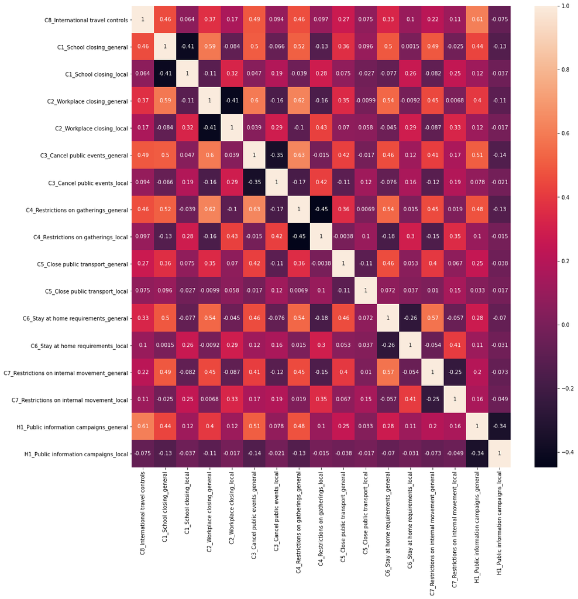

```python
#https://towardsdatascience.com/better-heatmaps-and-correlation-matrix-plots-in-python-41445d0f2bec
import seaborn as sn
import matplotlib.pyplot as plt
df = pd.DataFrame(data,columns=predictors)

fig_dims = (16, 16)
fig, ax = plt.subplots(figsize=fig_dims)

corrMatrix = df.corr()
sn.heatmap(corrMatrix, annot=True, ax=ax)
plt.show()
```

## Remove starts

```python
data = data[data['ConfirmedCases'] > 0]
dataDeaths = data[data['ConfirmedDeaths'] > 0]
```

### Remove outliers

Three standard deviations from the mean is a common cut-off in practice for identifying outliers in a Gaussian or Gaussian-like distribution.

The values are not cut off but replaced with the +- 3 standard deviations.

https://datascience.stackexchange.com/questions/60714/how-can-i-replace-outliers-with-maximum-non-outlier-value

```python
print(data[['ConfirmedCasesPctChange']].describe())
print(dataDeaths[['ConfirmedDeathsPctChange']].describe())
```

```
       ConfirmedCasesPctChange
count             10246.000000
mean                  0.275781
std                   1.668054
min                 -33.426117
25%                  -0.187812
50%                   0.027701
75%                   0.349474
max                  69.000000
       ConfirmedDeathsPctChange
count               9589.000000
mean                   0.322417
std                    2.124987
min                  -92.000000
25%                   -0.106090
50%                    0.000000
75%                    0.372549
max                   81.600000
```

```python
# calculate summary statistics https://machinelearningmastery.com/how-to-use-statistics-to-identify-outliers-in-data/
data_mean, data_std = np.mean(data['ConfirmedCasesPctChange']), np.std(data['ConfirmedCasesPctChange'])
# identify outliers - 3 Standard Deviations from the Mean
cut_off = data_std * 3
lower, upper = data_mean - cut_off, data_mean + cut_off
```

```python
#data = data[data['ConfirmedCasesPctChange'] > lower]
data['ConfirmedCasesPctChange'].loc[data['ConfirmedCasesPctChange'] < lower] = lower
#data = data[data['ConfirmedCasesPctChange'] < upper]
data['ConfirmedCasesPctChange'].loc[data['ConfirmedCasesPctChange'] > upper] = upper
```

```python
# calculate summary statistics https://machinelearningmastery.com/how-to-use-statistics-to-identify-outliers-in-data/
data_mean, data_std = np.mean(dataDeaths['ConfirmedDeathsPctChange']), np.std(dataDeaths['ConfirmedDeathsPctChange'])
# identify outliers
cut_off = data_std * 3
lower, upper = data_mean - cut_off, data_mean + cut_off
```

```python
#dataDeaths = dataDeaths[dataDeaths['ConfirmedDeathsPctChange'] > lower]
dataDeaths['ConfirmedDeathsPctChange'].loc[dataDeaths['ConfirmedDeathsPctChange'] < lower] = lower
#dataDeaths = dataDeaths[dataDeaths['ConfirmedDeathsPctChange'] < upper]
dataDeaths['ConfirmedDeathsPctChange'].loc[dataDeaths['ConfirmedDeathsPctChange'] > upper] = upper
```

```python
print(data[['ConfirmedCasesPctChange']].describe())
print(dataDeaths[['ConfirmedDeathsPctChange']].describe())
```

```
       ConfirmedCasesPctChange
count             10246.000000
mean                  0.214528
std                   0.858991
min                  -4.728137
25%                  -0.187812
50%                   0.027701
75%                   0.349474
max                   5.279700
       ConfirmedDeathsPctChange
count               9589.000000
mean                   0.301934
std                    1.141531
min                   -6.052211
25%                   -0.106090
50%                    0.000000
75%                    0.372549
max                    6.697045
```

### 3.10. Time Shift

The impact of the measure is delayed. We need to find the best fitting delay.

#### The target is shifted from 0 to 40 days.

```python
def day_shift_target(df: pd.DataFrame, days_shift: int, original_target: str, new_target: str) -> pd.DataFrame:
    df[new_target] = df.groupby('CountryRegionCode')[original_target].shift(days_shift)
    return df
```

```python
delay_confirmed_cases = range(40)
delay_confirmed_deaths = range(40)
target_confirmed_cases = []
target_confirmed_deaths = []
for delay in delay_confirmed_cases:
    new_target = 'ConfirmedCasesPctChange' + str(delay) #ConfirmedCasesPctChangeOrdinalCat
    target_confirmed_cases.append(new_target)
    data = day_shift_target(data, -delay, 'ConfirmedCasesPctChange', new_target)
for delay in delay_confirmed_deaths:
    new_target = 'ConfirmedDeathsPctChange' + str(delay) #ConfirmedDeathsPctChangeOrdinalCat
    target_confirmed_deaths.append(new_target)
    dataDeaths = day_shift_target(dataDeaths, -delay, 'ConfirmedDeathsPctChange', new_target)
dataShift = data.dropna(subset=[target_confirmed_cases[-1]]) # Drop all nans created because of time shift
dataDeathsShift = dataDeaths.dropna(subset=[target_confirmed_deaths[-1]])
```

### 3.11. Time Shift: The function for fitting

```python
import numpy as np
from scipy.optimize import curve_fit
import matplotlib.pyplot as plt
from sklearn.linear_model import LogisticRegression
from sklearn.linear_model import LinearRegression
from sklearn.metrics import r2_score
```

### 3.12. Time Shift: Fitting the different time shifts

```python
delay_scores_confirmed_cases = {}
delay_scores_confirmed_deaths = {}
cases_popt = {}
deaths_popt = {}
X = dataShift[['StringencyIndex']].values #predictors + tempCutsCols
Xdeaths = dataDeathsShift[['StringencyIndex']].values #predictors + tempCutsCols
for target in target_confirmed_cases:
    y = dataShift[target].values
    #mul_lr = LogisticRegression(
    #    multi_class='multinomial',
    #    solver='newton-cg',
    #    fit_intercept=True
    #)
    mul_lr = LinearRegression()
    mul_lr.fit(X, y)
    #y_rf = mul_lr.predict(data[['StringencyIndex']])
    delay_scores_confirmed_cases[target] = mul_lr.score(X, y)#r2_score(y, y_rf)
    cases_popt[target] = mul_lr.coef_
for target in target_confirmed_deaths:
    y = dataDeathsShift[target].values
    #mul_lr = LogisticRegression(
    #    multi_class='multinomial',
    #    solver='newton-cg',
    #    fit_intercept=True
    #)
    mul_lr = LinearRegression()
    mul_lr.fit(Xdeaths, y)
    #y_rf = mul_lr.predict(dataDeaths[['StringencyIndex']])
    delay_scores_confirmed_deaths[target] = mul_lr.score(Xdeaths, y) #r2_score(y, y_rf)
    deaths_popt[target] = mul_lr.coef_
```